# ECG classification

Laurent Cetinsoy - Datadidacte

```python
from IPython.display import HTML
```

```python
from scipy.stats import entropy
from sklearn.ensemble import RandomForestClassifier
from sklearn.model_selection import train_test_split
from sklearn.metrics import accuracy_score
import matplotlib.pyplot as plt
import numpy as np
import pandas as pd
import pywt
from sklearn.ensemble import GradientBoostingClassifier
from xgboost import XGBClassifier
from sklearn.preprocessing import LabelEncoder
from tensorflow.keras.models import Sequential
from tensorflow.keras.layers import Conv1D, MaxPooling1D, Flatten, Dense, Dropout
from tensorflow.keras.utils import to_categorical
```

[output not shown]

## A first naive model by extracting simple features

Your environment contains variables arr, nsr, and chf which respectively contain 10-second recordings of ECG signals extracted from three datasets on PhysioNet: one from a person suffering from arrhythmia, one from a person with a normal heart rhythm, and another from a person with heart failure.

Matplotlib subplots (or any other library), display these signals on three subfigures (the subplots should be called with the parameter nrows = 3). Can you find any differences between them?

```
[-0.345 -0.345 -0.345 ... -0.34  -0.33  -0.34 ]
[-0.395 -0.405 -0.425 ... -0.43  -0.465 -0.47 ]
[-0.275 -0.245 -0.285 ... -0.115 -0.065 -0.055]
```

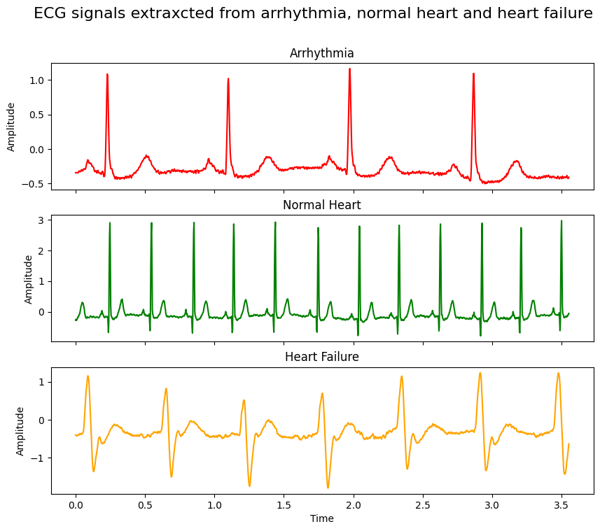

```python
arr = np.loadtxt('datasets/arr.txt')
chf = np.loadtxt('datasets/chf.txt')
nsr = np.loadtxt('datasets/nsr.txt')

print(arr)
print(chf)
print(nsr)



t = np.linspace(0, 10, len(arr), endpoint=False)
min_sec = min(len(arr), len(chf), len(nsr))

arr2 = arr[:min_sec]
chf2 = chf[:min_sec]
nsr2 = nsr[:min_sec]
t = t[:min_sec]

fig, axs = plt.subplots(nrows=3, figsize=(10, 8), sharex=True)
fig.suptitle("ECG signals extraxcted from arrhythmia, normal heart and heart failure", fontsize=16)
axs[0].plot(t, arr2, color="red")
axs[0].set_title("Arrhythmia")
axs[0].set_ylabel("Amplitude")
axs[2].plot(t, chf2, color="orange")
axs[2].set_title("Heart Failure")
axs[2].set_xlabel("Time")
axs[2].set_ylabel("Amplitude")
axs[1].plot(t, nsr2, color="green")
axs[1].set_title("Normal Heart")
axs[1].set_ylabel("Amplitude")


plt.show()
```

#### Yes we can see differences. The normal heart has big amplitude, the person with heart failure has less heartbeats less powerful, and the person with arrhythmia has even less heartbeats.

We want to extract features from the time series. For that we will use simple statistics.

Create a function named calculate_stats_features(x) that calculates some statistical features of a signal x using standard numpy functions: nanpercentile, nanmean, etc. calculate_stats_features will return a list of features in this order:

0. Max
1. Min
2. Mean
3. Median
4. Variance

```python
def calculate_stats_features(x):
    return [np.nanmax(x), np.nanmin(x), np.nanmean(x), np.nanmedian(x), np.nanvar(x)]
print(calculate_stats_features(arr))
```

```
[1.375, -0.59, -0.3120111111111112, -0.335, 0.039663552654320984]
```

Create a function named `calculate_zero_crossing(x)` that calculates the Zero Crossing of a signal x.

The zero crossing is defined as the number of times the signal changes sign. For this, you can use the signbit, diff, and nonzero functions from numpy.

```python
def calculate_zero_crossing(x):
    tmp = np.nonzero(np.diff(np.signbit(x)))[0]
    return len(tmp)
print(calculate_zero_crossing(arr))
```

```
22
```

Create a function named **calculate_rms(x)** that returns the Root Mean Square (RMS) of a signal x. We will use the nanmean function instead of the mean function from numpy.

```python
def calculate_rms(x):
    return np.sqrt(np.nanmean(x ** 2))
print(calculate_rms(arr))
```

```
0.37015467862923346
```

Create a function named calculate_entropy(x) that calculates the Shannon entropy of a signal x using the entropy function from scipy.stats.

```python
def calculate_entropy(x):
    hist, _ = np.histogram(x, bins=50, density=True)
    probabilities = hist / hist.sum()
    return entropy(probabilities)
print(calculate_entropy(arr))
```

```
2.4415460702497116
```

Create a function get_features(x) that combines the features calculated by all previous functions including caculate_stats_features.

```python
def get_features(x):
    res = calculate_stats_features(x)
    res.append(calculate_zero_crossing(x))
    res.append(calculate_rms(x))
    res.append(calculate_entropy(x))
    return res
print(get_features(arr))
```

```
[1.375, -0.59, -0.3120111111111112, -0.335, 0.039663552654320984, 22, 0.37015467862923346, 2.4415460702497116]
```

Load the small ecg dataset Use your fonction get_features create a new dataframe where you have all the feature as X and y as the label. Train a random forest on it after doing a train test split if the dataset is not too small

```python
ecg = pd.read_csv('datasets/ecg_small_dataset.csv')
print("Print the dataset")
print(ecg)

label = ecg.iloc[:, 1]
data = ecg.iloc[:, 2:]

print("Print les labels")
print(label)


np_arrays = [row for row in data.to_numpy()]
print("Print les signaux")
print(np_arrays)

x = []
for i in np_arrays:
    x.append(get_features(i))

print("Print les features")
print(x)

y = []
for j in label:
    y.append(j)

print("Print les labels")
print(y)

print("Dataset très petit donc peu de résultats")

x = np.array(x)
y = np.array(y)

x_train, x_test, y_train, y_test = train_test_split(x, y, test_size=0.3, random_state=42)

model = RandomForestClassifier(n_estimators=100, random_state=42)

model.fit(x_train, y_train)

y_pred = model.predict(x_test)
accuracy = accuracy_score(y_test, y_pred)

print(f"Prediction : {y_pred}")
print(f"Valeurs réelles: {y_test}")
print(f"Accuracy: {accuracy:.2f}")
```

```
Print the dataset
       0  1         2         3         4         5         6         7  \
0    205  1 -0.429539 -0.431368 -0.427633 -0.453029 -0.460659 -0.448497
1    205  1 -0.527040 -0.542357 -0.539678 -0.541406 -0.518841 -0.505650
2  chf14  2 -0.410425 -0.416644 -0.424048 -0.398195 -0.393680 -0.386315
3  chf14  2 -0.007009 -0.069041 -0.063572 -0.080944 -0.070556 -0.098701
4  18184  0 -0.325000 -0.395000 -0.255000 -0.335000 -0.375000 -0.335000
5  18184  0 -0.185000 -0.155000 -0.125000 -0.115000 -0.105000 -0.095000

          8         9  ...     15352     15353     15354     15355     15356  \
0 -0.469340 -0.475054  ... -0.299412 -0.341126 -0.364847 -0.360565 -0.358913
1 -0.523337 -0.532713  ... -0.523533 -0.542245 -0.544550 -0.523466 -0.510608
2 -0.371686 -0.377065  ... -0.288222 -0.742357 -1.088831 -1.347331 -1.349561
3 -0.090165 -0.108852  ... -1.906522 -1.694052 -1.534222 -1.338660 -1.167661
4 -0.285000 -0.275000  ... -0.085000 -0.105000 -0.135000 -0.135000 -0.155000
5 -0.085000 -0.065000  ... -0.105000 -0.135000 -0.145000 -0.145000 -0.155000

      15357     15358     15359     15360     15361
0 -0.406275 -0.452011 -0.440424 -0.417412 -0.419938
1 -0.497607 -0.508469 -0.495939 -0.479749 -0.484566
2 -1.165759 -1.004126 -0.829844 -0.671777 -0.536377
3 -0.989236 -0.777201 -0.544748 -0.313120 -0.032588
4 -0.155000 -0.135000 -0.145000 -0.125000 -0.115000
5 -0.165000 -0.165000 -0.145000 -0.155000 -0.135000

[6 rows x 15362 columns]
Print les labels
0    1
1    1
2    2
3    2
4    0
5    0
Name: 1, dtype: int64
Print les signaux
[array([-0.429539  , -0.43136825, -0.42763256, ..., -0.44042408,
       -0.41741177, -0.41993835]), array([-0.52703973, -0.5423572 , -0.53967817, ..., -0.49593937,
       -0.47974934, -0.48456588]), array([-0.41042485, -0.41664449, -0.42404757, ..., -0.82984363,
       -0.67177738, -0.53637735]), array([-0.00700897, -0.06904099, -0.06357223, ..., -0.5447477 ,
       -0.3131197 , -0.03258846]), array([-0.325, -0.395, -0.255, ..., -0.145, -0.125, -0.115]), array([-0.185, -0.155, -0.125, ..., -0.145, -0.155, -0.135])]
Print les features
[[1.002117573015905, -0.5927308072482946, -0.3407592592592593, -0.37605700886292914, 0.03263429813237712, 358, 0.3856827334783037, 2.245176130495881], [-0.2815212090436512, -0.923733716922188, -0.5104682870370371, -0.5052932947467894, 0.0036579037097007852, 0, 0.5140386909370029, 2.82864521138806], …
Print les labels
[1, 1, 2, 2, 0, 0]
Dataset très petit donc peu de résultats
Prediction : [2 2]
Valeurs réelles: [1 1]
Accuracy: 0.00
```

Now you have a first pipeline, do the same on the full dataset Report the train and test loss

```python
ecg = pd.read_csv('datasets/ECG-laurent.csv')
print("Print the dataset")
#print(ecg)

label = ecg.iloc[:, 1]
data = ecg.iloc[:, 2:]

print("Print les labels")
print(label)


np_arrays = [row for row in data.to_numpy()]
print("Print les signaux")
print(np_arrays)

x = []
for i in np_arrays:
    x.append(get_features(i))

print("Print les features")
print(x)

y = []
for j in label:
    y.append(j)

print("Print les labels")
print(y)


x = np.array(x)
y = np.array(y)

x_train, x_test, y_train, y_test = train_test_split(x, y, test_size=0.3, random_state=42)

model = RandomForestClassifier(n_estimators=100, random_state=42)

model.fit(x_train, y_train)

y_pred = model.predict(x_test)
accuracy = accuracy_score(y_test, y_pred)

print(f"Prediction : {y_pred}")
print(f"Valeurs réelles: {y_test}")
print(f"Accuracy: {accuracy:.2f}")
```

[output not shown]

[output cut: 96 more lines]

[output not shown]

try to tweak the model hyperparameter to see if it works

```python
for i in range(10, 200, 10):
    model = RandomForestClassifier(n_estimators=i, random_state=42)
    model.fit(x_train, y_train)
    y_pred = model.predict(x_test)
    accuracy = accuracy_score(y_test, y_pred)
    print(f"Accuracy: {accuracy:.2f} , estimator:{i}")
```

```
Accuracy: 0.78 , estimator:10
Accuracy: 0.82 , estimator:20
Accuracy: 0.80 , estimator:30
Accuracy: 0.82 , estimator:40
Accuracy: 0.80 , estimator:50
Accuracy: 0.80 , estimator:60
Accuracy: 0.78 , estimator:70
Accuracy: 0.78 , estimator:80
Accuracy: 0.78 , estimator:90
Accuracy: 0.78 , estimator:100
Accuracy: 0.78 , estimator:110
Accuracy: 0.76 , estimator:120
Accuracy: 0.76 , estimator:130
Accuracy: 0.73 , estimator:140
Accuracy: 0.73 , estimator:150
Accuracy: 0.73 , estimator:160
Accuracy: 0.73 , estimator:170
Accuracy: 0.76 , estimator:180
Accuracy: 0.76 , estimator:190
```

#### The accuracy is better with estimator=20

## Fourier transform features

We want now to see if a model using only fourier transform could work.

create a function get_fourier_coefficients(ecg)

```python
def get_fourier_coefficients(ecg):
    four = np.fft.rfft(ecg)
    coef = np.abs(four)
    return coef

print(get_fourier_coefficients(x))
```

[output not shown]

[output cut: 269 more lines]

[output not shown]

Using this function create a dataframe df_fourrier containing the fourrier transform coefficients and the label

```python
fourier_coef = []
for i in data.to_numpy():
    coef = get_fourier_coefficients(i)
    fourier_coef.append(coef)
df_fourrier = pd.DataFrame(fourier_coef)
df_fourrier['label'] = label.reset_index(drop=True)
print(df_fourrier)
```

```
                0            1            2            3            4  \
0    17599.976889  1850.171567   295.333800  1185.545859   926.385162
1    14484.396444  4137.499334  2152.391165  2520.424900  2066.642615
2    10683.818667   400.463461   481.532272   729.461562   964.923609
3     3536.462222   313.204866   531.520312   667.082007   647.502832
4     9756.496000   303.329945   596.020424   609.179346   380.981983
..            ...          ...          ...          ...          ...
157  14269.954560   593.412836   760.985169  1294.411838  1341.284484
158  17730.076160   378.721372   408.463206   581.751509   276.486875
159  11277.319680  1434.196761  2603.621630   769.678837  1109.373133
160  22526.704640   289.587563   621.209385   322.026792   332.194610
161  17308.451840   683.773983  1434.478998  2887.008289   976.316846

               5            6            7            8            9  ...  \
0     538.293366   828.133738   689.752202  1559.152560   545.466498  ...
```

[output cut: 38 more lines]

Try to train a model using the Fourrier coefficient

```python
X = df_fourrier.iloc[:, :-1]
Y = df_fourrier['label']
X_train2, X_test2, y_train2, y_test2 = train_test_split(X, Y, test_size=0.3, random_state=42)
model2 = RandomForestClassifier(n_estimators=100, random_state=42)
model2.fit(X_train2, y_train2)
y_pred2 = model2.predict(X_test2)
accuracy2 = accuracy_score(y_test2, y_pred2)
print(f"Accuracy: {accuracy2:.2f}")
```

```
Accuracy: 0.73
```

Try to learn a model using both fourrier coefficient and the features from the previous sections. Does it work ?

```python
X_combine = np.hstack((X, x))
y_combine = y
X_train3, X_test3, y_train3, y_test3 = train_test_split(X_combine, y_combine, test_size=0.3, random_state=42)
model3 = RandomForestClassifier(n_estimators=100, random_state=42)
model3.fit(X_train3, y_train3)
y_pred3 = model3.predict(X_test3)
accuracy3 = accuracy_score(y_test3, y_pred3)
print(f"Accuracy: {accuracy3:.2f}")
```

```
Accuracy: 0.69
```

```python
for i in range(10, 200, 10):
    model3 = RandomForestClassifier(n_estimators=i, random_state=42)
    model3.fit(X_train3, y_train3)
    y_pred3 = model3.predict(X_test3)
    accuracy3 = accuracy_score(y_test3, y_pred3)
    print(f"Accuracy: {accuracy3:.2f} , estimator:{i}")
```

```
Accuracy: 0.67 , estimator:10
Accuracy: 0.69 , estimator:20
Accuracy: 0.69 , estimator:30
Accuracy: 0.69 , estimator:40
Accuracy: 0.67 , estimator:50
Accuracy: 0.65 , estimator:60
Accuracy: 0.67 , estimator:70
Accuracy: 0.69 , estimator:80
Accuracy: 0.69 , estimator:90
Accuracy: 0.69 , estimator:100
Accuracy: 0.69 , estimator:110
Accuracy: 0.69 , estimator:120
Accuracy: 0.69 , estimator:130
Accuracy: 0.69 , estimator:140
Accuracy: 0.69 , estimator:150
Accuracy: 0.69 , estimator:160
Accuracy: 0.69 , estimator:170
Accuracy: 0.69 , estimator:180
Accuracy: 0.69 , estimator:190
```

#### Here we use all the coefficients. If we take less coefficients, the result will be better

## Wavelets

We now wants to use another signal decomposition which are called wavelet. Wavelet are a multi-scale function decomposition on a familly of functions generated from what is called a mother wavelet.

Using PyWavelet make a function get_wavelet_coefficients(ecg) that returns the wavelet coefficient of a given ECG

```python
print(type(ecg))
print(ecg.shape)
def get_wavelet_coefficients(ecg):
    ecg = pd.to_numeric(ecg, errors='coerce')
    ecg = ecg.dropna()
    ecg = ecg.to_numpy()
    coef = pywt.wavedec(ecg, wavelet='db4', level=4)
    flat = np.concatenate([c for c in coef])
    return flat
```

```
<class 'pandas.core.frame.DataFrame'>
(162, 65538)
```

Using the get_wavelet_coefficients, create a dataframe when the features are the coefficients and include the label

```python
wavelet_r = []
for _, row in data.iterrows():
    coef = get_wavelet_coefficients(row)
    wavelet_r.append(coef)
wavelet_df = pd.DataFrame(wavelet_r)

#print(wavelet_df)

wavelet_df['label'] = label.reset_index(drop=True)

print(wavelet_df)
```

```
            0         1         2         3         4         5         6  \
0   -0.228740 -0.190008 -0.179619 -0.226580 -0.031340 -1.018605 -0.444753
1   -2.284291 -2.311781 -2.299607 -2.283637 -2.467491 -1.493960 -3.442873
2   -0.821863 -0.796012 -0.774485 -0.775475 -0.978186 -0.179384 -0.315090
3    0.348926  0.375198  0.371578  0.332356  0.535287 -0.082380  2.922918
4   -1.643063 -1.666765 -1.676780 -1.630421 -1.849698 -0.928686  0.243894
..        ...       ...       ...       ...       ...       ...       ...
157 -1.256411 -1.176086 -1.000601 -1.271352 -0.768256 -2.578013  0.597282
158 -1.547153 -1.558670 -1.539930 -1.546184 -1.587573 -1.424208 -1.299591
159 -0.365921 -0.357162 -0.362281 -0.369334 -0.313935 -0.525250 -0.576419
160  0.731175  0.785912  0.819470  0.593377  1.540172 -1.551643 -0.743050
161  0.690330  0.747722  0.748915  0.634233  1.083086 -0.216203 -2.680500

            7         8         9  ...     65553     65554     65555  \
0   -2.368966 -1.634749 -0.977731  ...  0.020990 -0.037387  0.028253
```

[output cut: 25 more lines]

Train a random forest classifier with such features. DOes the model work

```python
X4 = wavelet_df.iloc[:, :-1]
Y4 = wavelet_df['label']
X_train4, X_test4, y_train4, y_test4 = train_test_split(X4, Y4, test_size=0.3, random_state=42)
model4 = RandomForestClassifier(n_estimators=100, random_state=42)
model4.fit(X_train4, y_train4)
y_pred4 = model4.predict(X_test4)
accuracy4 = accuracy_score(y_test4, y_pred4)
print(f"Accuracy: {accuracy4:.2f}")
```

```
Accuracy: 0.63
```

```python
for i in range(10, 200, 10):
    model4 = RandomForestClassifier(n_estimators=i, random_state=42)
    model4.fit(X_train4, y_train4)
    y_pred4 = model4.predict(X_test4)
    accuracy4 = accuracy_score(y_test4, y_pred4)
    print(f"Accuracy: {accuracy4:.2f} , estimator:{i}")
```

```
Accuracy: 0.55 , estimator:10
Accuracy: 0.63 , estimator:20
Accuracy: 0.65 , estimator:30
Accuracy: 0.63 , estimator:40
Accuracy: 0.65 , estimator:50
Accuracy: 0.61 , estimator:60
Accuracy: 0.61 , estimator:70
Accuracy: 0.61 , estimator:80
Accuracy: 0.61 , estimator:90
Accuracy: 0.63 , estimator:100
Accuracy: 0.61 , estimator:110
Accuracy: 0.63 , estimator:120
Accuracy: 0.65 , estimator:130
Accuracy: 0.63 , estimator:140
Accuracy: 0.63 , estimator:150
Accuracy: 0.63 , estimator:160
Accuracy: 0.63 , estimator:170
Accuracy: 0.63 , estimator:180
Accuracy: 0.63 , estimator:190
```

Add one or several of the previous feature functions and try to train another model

```python
def combine(ecg):
    wave = get_wavelet_coefficients(ecg)
    stat = calculate_stats_features(ecg)
    zer = calculate_zero_crossing(ecg)
    rms = calculate_rms(ecg)
    ent = calculate_entropy(ecg)
    return np.concatenate([wave, stat, [zer, rms, ent]])

ecg = pd.read_csv('datasets/ECG-laurent.csv')
label = ecg.iloc[:, 1]
data = ecg.iloc[:, 2:]

combined = []
for _, row in data.iterrows():
    f = combine(row)
    combined.append(f)
max_len = max(len(f) for f in combined)
padded_features = [np.pad(f, (0, max_len - len(f))) for f in combined]
combined_df = pd.DataFrame(padded_features)
combined_df['label'] = label.reset_index(drop=True)

#print(combined_df)

x = combined_df.iloc[:, :-1]
y = combined_df['label']
x_train, x_test, y_train, y_test = train_test_split(x, y, test_size=0.3, random_state=42)

model5 = GradientBoostingClassifier(n_estimators=100, learning_rate=0.1, max_depth=3, random_state=42)
model5.fit(x_train, y_train)
y_pred = model5.predict(x_test)
accuracy = accuracy_score(y_test, y_pred)
print(f"Accuracy GradienBoostingClassifier: {accuracy:.2f}")

model6 = XGBClassifier(n_estimators=100, learning_rate=0.1, max_depth=3, random_state=42, use_label_encoder=False, eval_metric="logloss")
model6.fit(x_train, y_train)
y_pred = model6.predict(x_test)
accuracy2 = accuracy_score(y_test, y_pred)
print(f"Accuracy XGBoost: {accuracy:.2f}")
```

```
Accuracy GradienBoostingClassifier: 0.51
```

```
Accuracy XGBoost: 0.51
```

## Deep learning (1D CNN)

Now we want to see if we can skip all theses feature engineering techniques ! Design and train a multi-layer one dimensional CNN using the raw ECG signal as features.

Could you reach or surpass the feature based models ?

```python
A = data.to_numpy()
B = label.to_numpy()

max_len = max([len(row) for row in A])
A = np.array([np.pad(row, (0, max_len - len(row))) for row in A])



enco = LabelEncoder()
B = enco.fit_transform(B)
B = to_categorical(B)

X_train, X_test, y_train, y_test = train_test_split(A, B, test_size=0.3, random_state=42)
print(X_train.shape)
print(X_test.shape)
X_train = X_train[:, :, np.newaxis]
X_test = X_test[:, :, np.newaxis]



model7 = Sequential([
    Conv1D(filters=32, kernel_size=5, activation='relu', input_shape=(X_train.shape[1], 1)),
    MaxPooling1D(pool_size=2),
    Conv1D(filters=64, kernel_size=5, activation='relu'),
    MaxPooling1D(pool_size=2),
    Conv1D(filters=128, kernel_size=5, activation='relu'),
    MaxPooling1D(pool_size=2),
    Conv1D(filters=256, kernel_size=5, activation='relu'),
    MaxPooling1D(pool_size=2),
    Flatten(),
    Dense(256, activation='relu'),
    Dropout(0.5),
    Dense(y_train.shape[1], activation='softmax')
])

model7.compile(optimizer='adam', loss='categorical_crossentropy', metrics=['accuracy'])
h = model7.fit(X_train, y_train, epochs=10, batch_size=32, validation_data=(X_test, y_test), verbose=1)
loss, accuracy = model7.evaluate(X_test, y_test, verbose=0)
print(f"Accuracy of the CNN Model: {accuracy:.2f}")
```

```
(113, 65536)
(49, 65536)
```

```
4/4 ━━━━━━━━━━━━━━━━━━━━ 166s 41s/step - accuracy: 0.4287 - loss: 14.6418 - val_accuracy: 0.2041 - val_loss: 2.7756
4/4 ━━━━━━━━━━━━━━━━━━━━ 212s 53s/step - accuracy: 0.3039 - loss: 2.0788 - val_accuracy: 0.6327 - val_loss: 0.9676
4/4 ━━━━━━━━━━━━━━━━━━━━ 228s 58s/step - accuracy: 0.6876 - loss: 0.8924 - val_accuracy: 0.6122 - val_loss: 0.8262
4/4 ━━━━━━━━━━━━━━━━━━━━ 214s 57s/step - accuracy: 0.7261 - loss: 0.6919 - val_accuracy: 0.6735 - val_loss: 0.6464
4/4 ━━━━━━━━━━━━━━━━━━━━ 520s 151s/step - accuracy: 0.8334 - loss: 0.3976 - val_accuracy: 0.7347 - val_loss: 0.5265
4/4 ━━━━━━━━━━━━━━━━━━━━ 357s 46s/step - accuracy: 0.9148 - loss: 0.2789 - val_accuracy: 0.7551 - val_loss: 0.5297
4/4 ━━━━━━━━━━━━━━━━━━━━ 189s 48s/step - accuracy: 0.9119 - loss: 0.2170 - val_accuracy: 0.7347 - val_loss: 0.6483
4/4 ━━━━━━━━━━━━━━━━━━━━ 156s 39s/step - accuracy: 0.9217 - loss: 0.1639 - val_accuracy: 0.6939 - val_loss: 0.6087
4/4 ━━━━━━━━━━━━━━━━━━━━ 169s 41s/step - accuracy: 0.9221 - loss: 0.1602 - val_accuracy: 0.7959 - val_loss: 0.4406
4/4 ━━━━━━━━━━━━━━━━━━━━ 161s 34s/step - accuracy: 0.9706 - loss: 0.0868 - val_accuracy: 0.7551 - val_loss: 0.6503
Accuracy of the CNN Model: 0.76
```